# R Notebook

# Prova de Especialização

- Primeiramente vamos importar os dados:

```r
wine.data <- readxl::read_excel('exe.xlsx', 'D')
head(wine.data)
```

| Clari | Aroma | Corpo | Sabor | Afina | Qua |
| --- | --- | --- | --- | --- | --- |
| 1 | 3.3 | 2.8 | 3.1 | 4.1 | 9.8 |
| 1 | 4.4 | 4.9 | 3.5 | 3.9 | 12.6 |
| 1 | 3.9 | 5.3 | 4.8 | 4.7 | 11.9 |
| 1 | 3.9 | 2.6 | 3.1 | 3.6 | 11.1 |
| 1 | 5.6 | 5.1 | 5.5 | 5.1 | 13.3 |
| 1 | 4.6 | 4.7 | 5.0 | 4.1 | 12.8 |

Os dados do vinho são referentes aos atributos Claridade, Aroma, Corpo, Sabor, Afinação e Qualidade. O nosso objetivo no estudo é relacionar os atributos Claridades, Aroma, Corpo, Sabor e Afinação com a Qualidade do vinho, ou seja, quais desses atributos interferem na qualidade.

#### **a) Estime $\beta$ pelo método dos mínimos quadrados. Explique o procedimento.**

Para isso, precisa-se calcular a *Qualidade Estimada* ($\widehat{Y}$), que é:

$$\widehat{Y} = \beta0 + \beta1*Claridade + \beta2*Aroma + \beta3*Corpo + \beta4*Sabor + \beta5*Afinacao$$

```r
Claridade <- wine.data$Clari
Aroma <- wine.data$Aroma
Corpo <- wine.data$Corpo
Sabor <- wine.data$Sabor
Afinacao <- wine.data$Afina
Y <- wine.data$Qua

desvioY <- function(betas) {
  Y.Estimado <- betas[1] + betas[2]*Claridade + betas[3]*Aroma + betas[4]*Corpo + betas[5]*Sabor + betas[6]*Afinacao
  S <- sum( (Y - Y.Estimado)^2 )
}
```

A função `desvioY`, calcula o resíduo dos Y ($Qualidade Real - Qualidade Estimada$), eleva ao quadrado para não haver números negativos eliminando números positivos e por fim soma tudo. É essa função que se gostaria que fosse a menor possível.

Ou seja, o objetivo é saber os valores dos $\widehat{\beta1}$, $\widehat{\beta2}$, $\widehat{\beta3}$, $\widehat{\beta4}$, $\widehat{\beta5}$ que minimize a soma S.

Aplicando a função `optim` temos os betas procurados:

```r
R.2 <- optim(par = c(1,1,1,1,1,1), fn = desvioY, method = "L-BFGS-B")
R.2$par
```

```
## [1]  3.9962004  2.3384721  0.4826345  0.2732280  1.1682793 -0.6837678
```

Executando a regressão linear para ter valores matemáticos mais exatos, temos:

```r
U <- lm(Y~Claridade+Aroma+Corpo+Sabor+Afinacao)
U$coefficients
```

```
## (Intercept)   Claridade       Aroma       Corpo       Sabor    Afinacao
##   3.9968648   2.3394535   0.4825505   0.2731612   1.1683238  -0.6840102
```

Comparando os valores dos $\widehat{betas}$ pelo método dos mínimos quadrados com os valores reais da regressão linear, observamos que os valores estão bem próximos.

#### **b) Você concorda que uma relação linear é adequada? Como avaliaria no caso da Regressão Linear Múltipla?**

Caso tivéssemos a variável de resposta Y relacionada com uma única variável independente X, seria suficiente fazer um diagrama de dispersão do relacionando Y com X. Porém, nós temos 5 variáveis (dimensões), sem adicionar o Y.

Portanto, precisamos fazer um gráfico de dispersão do resíduo com cada uma das variáveis independentes (Claridade, Aroma, Corpo, Sabor, Afinacao), esperando um padrão aleatório em cada um desses gráficos.

Lembrando que *Resídio* é tudo que não foi explicado da qualidade do vinho.

Plotando os gráficos relacionando as variávies independentes (Claridade, Aroma, Corpo, Sabor, Afinacao) em relação com o Resíduo *não* se observa um padrão linear em nenhuma delas.

Logo, é razoável se trabalhar com uma Regressão Linear, pois o que se sobrou no resíduo não possui efeito não linear no modelo.

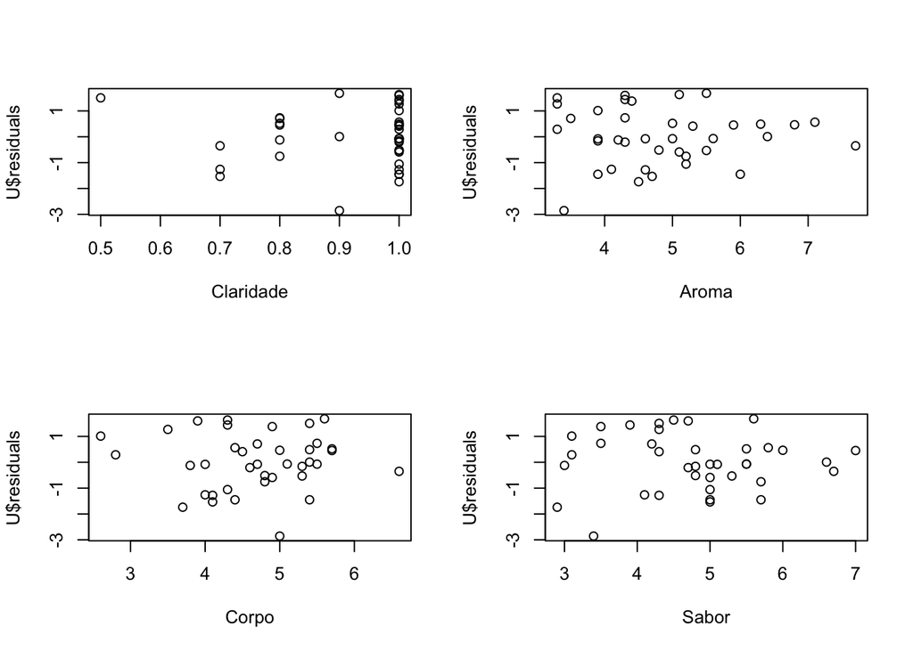

```r
par(mfrow=c(2,2))

plot(Claridade, U$residuals)
plot(Aroma, U$residuals)
plot(Corpo, U$residuals)
plot(Sabor, U$residuals)
```

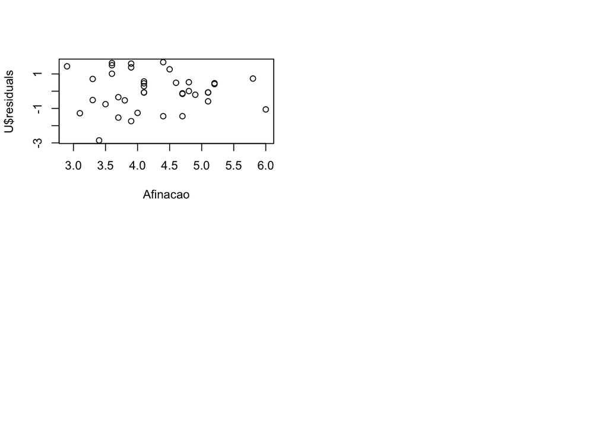

```r
plot(Afinacao, U$residuals)
```

#### **c)Estime a variância da componente erro utilizando um estimador não viciado ($\sigma^2$). Explique o procedimento**

A variância não viciada do componente erro trata-se da variância dos resíduos corrigida pelo número de parâmetro estimados, logo:

*Observação: utilizamos do artifício matemático de multiplicar por (n -1) para eliminar o denominador da fórmula utilizada no cálculo da variância dos resíduos.*

```r
n <- 38
quantidadeParametrosEstimados <- 6
sigma.2 <- var(U$residuals) * (n -1 ) / (n - quantidadeParametrosEstimados)
sigma.2
```

```
## [1] 1.3515
```

#### **d) Estime a variância de $\widehat{\beta_4}$ (relativo ao sabor). Explique o procedimento.**

Iremos estimar a variância através da matriz utilizando a estimativa de mínimos quadrados de $\beta = (X'X)^-1$

- Para obtermos a Matriz de planejamento X:

```r
X <- model.matrix(U)
head.matrix(X)
```

```
##   (Intercept) Claridade Aroma Corpo Sabor Afinacao
## 1           1         1   3.3   2.8   3.1      4.1
## 2           1         1   4.4   4.9   3.5      3.9
## 3           1         1   3.9   5.3   4.8      4.7
## 4           1         1   3.9   2.6   3.1      3.6
## 5           1         1   5.6   5.1   5.5      5.1
## 6           1         1   4.6   4.7   5.0      4.1
```

- Calculando a transposta da matriz:

```r
X.linha <- t(X)
head.matrix(X.linha)
```

```
##               1   2   3   4   5   6   7   8   9  10  11  12  13  14  15  16  17
## (Intercept) 1.0 1.0 1.0 1.0 1.0 1.0 1.0 1.0 1.0 1.0 1.0 1.0 1.0 1.0 1.0 1.0 1.0
## Claridade   1.0 1.0 1.0 1.0 1.0 1.0 1.0 1.0 1.0 1.0 1.0 0.5 0.8 0.7 1.0 0.9 1.0
## Aroma       3.3 4.4 3.9 3.9 5.6 4.6 4.8 5.3 4.3 4.3 5.1 3.3 5.9 7.7 7.1 5.5 6.3
## Corpo       2.8 4.9 5.3 2.6 5.1 4.7 4.8 4.5 4.3 3.9 4.3 5.4 5.7 6.6 4.4 5.6 5.4
## Sabor       3.1 3.5 4.8 3.1 5.5 5.0 4.8 4.3 3.9 4.7 4.5 4.3 7.0 6.7 5.8 5.6 4.8
## Afinacao    4.1 3.9 4.7 3.6 5.1 4.1 3.3 5.2 2.9 3.9 3.6 3.6 4.1 3.7 4.1 4.4 4.6
##              18  19  20  21  22  23  24  25  26  27  28  29  30  31  32  33  34
## (Intercept) 1.0 1.0 1.0 1.0 1.0 1.0 1.0 1.0 1.0 1.0 1.0 1.0 1.0 1.0 1.0 1.0 1.0
## Claridade   1.0 1.0 0.9 0.9 1.0 0.7 0.7 1.0 1.0 1.0 1.0 1.0 1.0 1.0 0.8 1.0 1.0
## Aroma       5.0 4.6 3.4 6.4 5.5 4.7 4.1 6.0 4.3 3.9 5.1 3.9 4.5 5.2 4.2 3.3 6.8
## Corpo       5.5 4.1 5.0 5.4 5.3 4.1 4.0 5.4 4.6 4.0 4.9 4.4 3.7 4.3 3.8 3.5 5.0
## Sabor       5.5 4.3 3.4 6.6 5.3 5.0 4.1 5.7 4.7 5.1 5.0 5.0 2.9 5.0 3.0 4.3 6.0
## Afinacao    4.1 3.1 3.4 4.8 3.8 3.7 4.0 4.7 4.9 5.1 5.1 4.4 3.9 6.0 4.7 4.5 5.2
##              35  36  37  38
## (Intercept) 1.0 1.0 1.0 1.0
## Claridade   0.8 0.8 0.8 0.8
## Aroma       5.0 3.5 4.3 5.2
## Corpo       5.7 4.7 5.5 4.8
## Sabor       5.5 4.2 3.5 5.7
## Afinacao    4.8 3.3 5.8 3.5
```

- Multiplica a tranposta (X’) por X:

```r
X1 <- X.linha%*%X
head.matrix(X1)
```

```
##             (Intercept) Claridade  Aroma  Corpo  Sabor Afinacao
## (Intercept)        38.0     35.10 184.20 178.00 181.20   161.70
## Claridade          35.1     32.99 170.45 163.25 166.97   149.98
## Aroma             184.2    170.45 936.24 880.95 908.67   789.78
## Corpo             178.0    163.25 880.95 858.92 869.05   760.86
## Sabor             181.2    166.97 908.67 869.05 903.14   776.10
## Afinacao          161.7    149.98 789.78 760.86 776.10   708.23
```

- Calculando a inversa de $(X'X)^-1$:

```r
X.inversa <- solve(X1)
head.matrix(X.inversa)
```

```
##             (Intercept)   Claridade        Aroma       Corpo       Sabor
## (Intercept)  3.68538435 -2.16087923  0.056193065 -0.29618518 -0.02052109
## Claridade   -2.16087923  2.22687731 -0.081481738  0.16333471  0.01106341
## Aroma        0.05619307 -0.08148174  0.054922315 -0.01420775 -0.03576244
## Corpo       -0.29618518  0.16333471 -0.014207755  0.08183244 -0.02875529
## Sabor       -0.02052109  0.01106341 -0.035762437 -0.02875529  0.06859675
## Afinacao    -0.10580781 -0.07494938 -0.002367866 -0.00752418 -0.00205549
##                 Afinacao
## (Intercept) -0.105807813
## Claridade   -0.074949380
## Aroma       -0.002367866
## Corpo       -0.007524180
## Sabor       -0.002055490
## Afinacao     0.054417686
```

- Calculando a variância do modelo:

```r
U.summary <- summary(U)
variancia.modelo <- (U.summary$sigma)^2
variancia.modelo
```

```
## [1] 1.3515
```

- Por fim, calculando a variância de $\widehat{\beta_4}$. Observamos na matriz *X.inversa* (calculada acima) que o valor da estimativa do mínimo quadrado de $\widehat{\beta_4}$ (sabor) encontra-se na linha 5 e coluna 5.

```r
beta4.variancia <- variancia.modelo * X.inversa[5,5]
beta4.variancia
```

```
## [1] 0.09270852
```